# VAF calculation report

30 June 2021

Number of high confidence EWSR1/FLI1 fusion detections = **2**

Number of low confidence EWSR1/FLI1 fusion detections = **5**

#### **Read filtering steps**

1. Removed mate of double-split supplement alignments
2. Removed multimapping (mapq = 0) read pairs.
3. Removed reads with > 1 supplementary alignments.
4. Removed reads with only supplementary alignments.
5. Removed unpaired reads.
6. Removed split supplementary alignments without matching primary alignment pair.
7. Removed split read pairs from discordant pairs.
8. Removed reads not mapping to either chr11 or chr22.
9. Created groups of concordant and discordant read pairs
10. Created group of split primary alignment read pairs (read names fetched from split supplementary alignments)
11. Created group of non-split concordant read pairs

Ended up with three groups contributing to VAF calculations:  
a) non-split concordant read pairs  
b) non-split discordant read pairs  
c) split read pairs (mixture of concordant and discordant pairs)

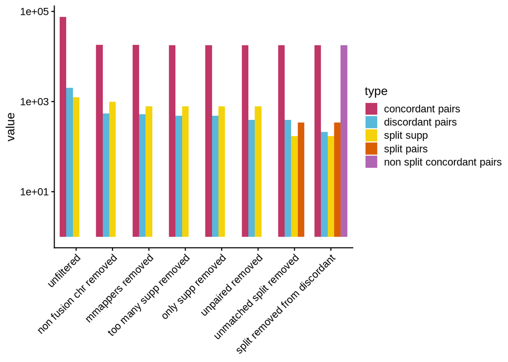

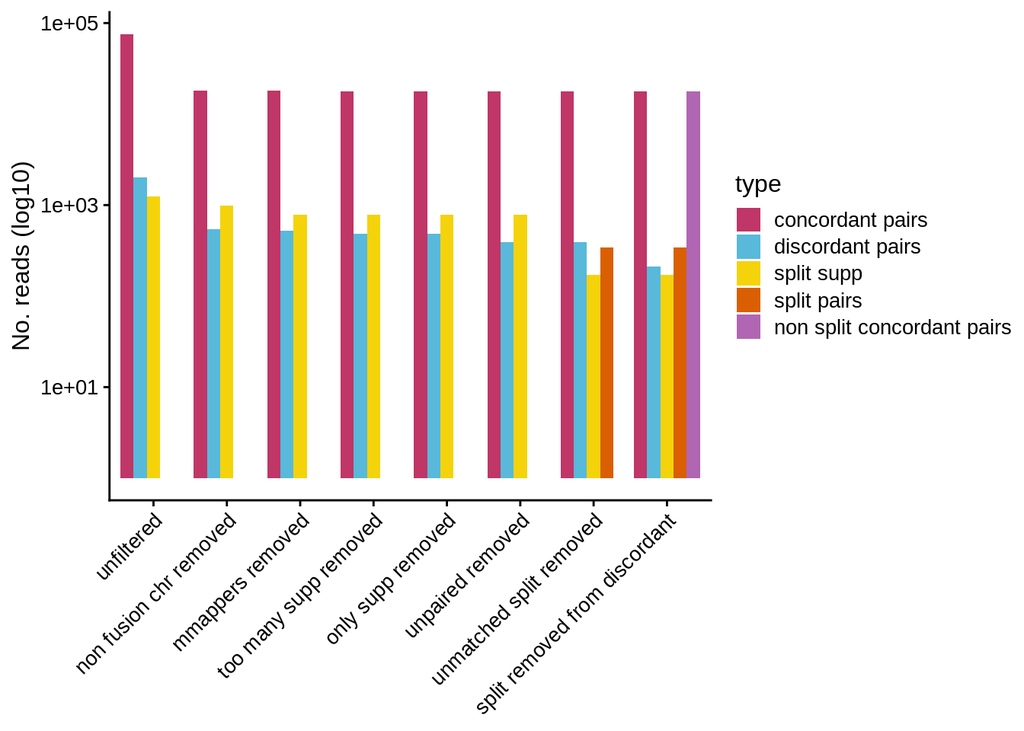

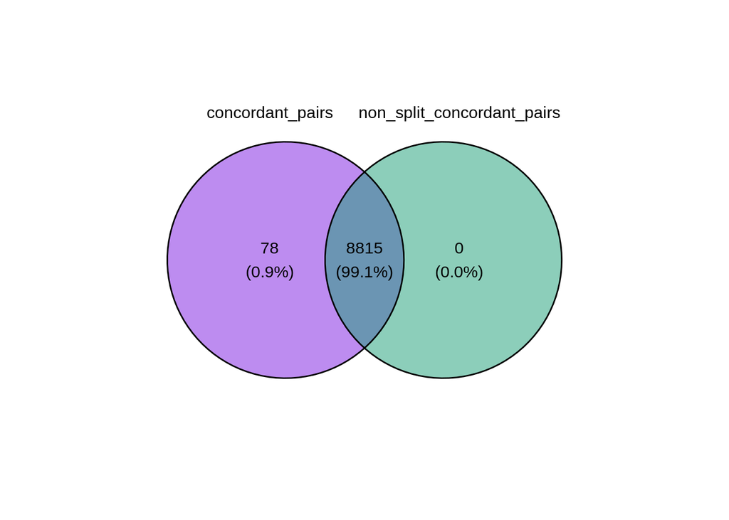

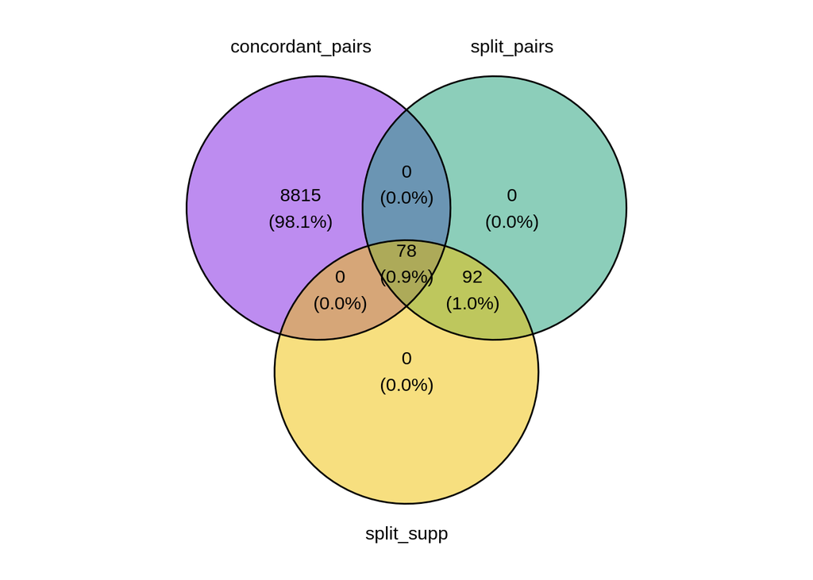

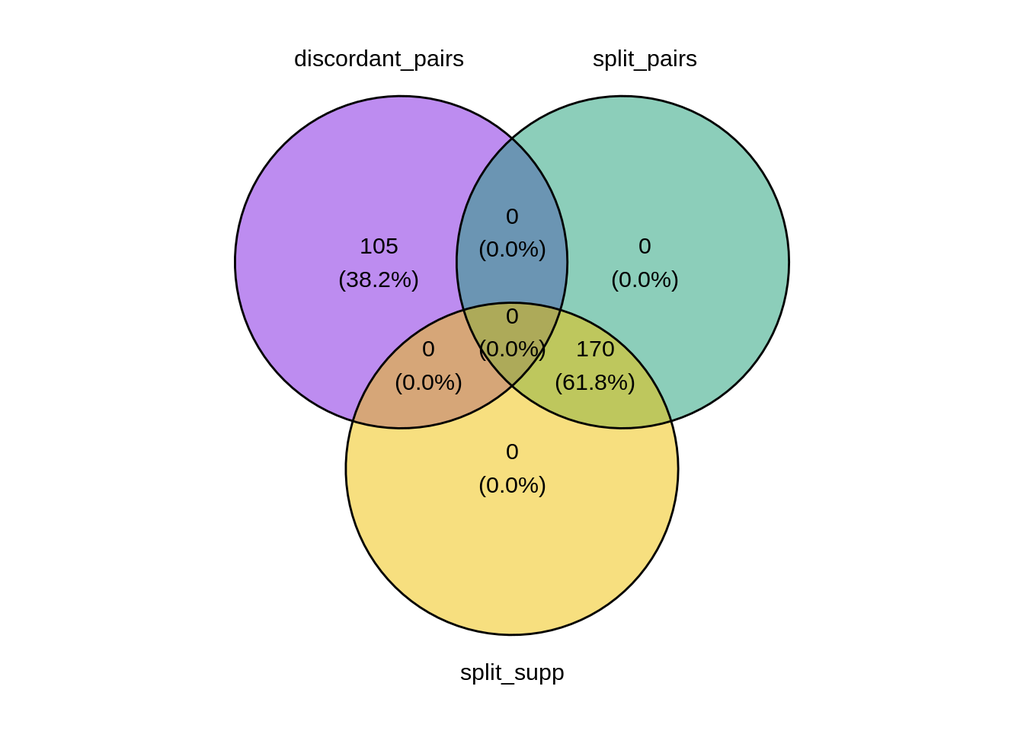

#### **Read categorisation**

The following reads were separated for VAF calculations of each fusion breakpoint:

1. Fusion supporting reads
1. Split reads mapping over fusion breakpoints, with each overlap at least 19 bp long either side of the breakpoint
2. Discordant reads spanning fusion breakpoint:  
   i) one read maps completely within EWSR1, and one completely within FLI1, within 100 bp of breakpoint)  
   ii) similar to (i), but one or both non-split discordant reads overlap the breakpoint
2. Non-supporting reads
1. Non-split reads mapping over fusion breakpoints, with each overlap at least 19 bp long either side of the breakpoint, both mapping to EWSR1 only
2. Non-discordant reads spanning fusion breakpoint (i.e. both reads map completely within EWSR1, either side of breakpoint)

#### **VAF calculation**

Fusion-associated reads:

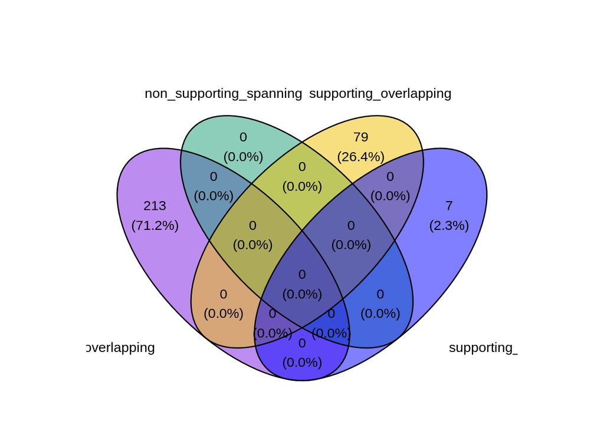